# Final Project

### Model #4

Let’s enhance our regression model by including average teacher salary and low income as a control variable alongside per pupil expenditure. Once the model is fitted, we’ll visualize and analyze the summary test statistics.

```r
# Fitting in the model with data.

model_2 <- lm(Final_df$`Avg SAT Score` ~ Final_df$`Per Pupil Expenditure` + Final_df$`Avg. Salary` + Final_df$`Low Income`, data = Final_df)

# Viewing summary statistics of the regression analysis.

summary(model_2)
```

```
Call:
lm(formula = Final_df$`Avg SAT Score` ~ Final_df$`Per Pupil Expenditure` +
    Final_df$`Avg. Salary` + Final_df$`Low Income`, data = Final_df)

Residuals:
    Min      1Q  Median      3Q     Max
-71.431 -19.095  -1.651  21.733 116.730

Coefficients:
                                   Estimate Std. Error t value Pr(>|t|)
(Intercept)                       5.994e+02  1.748e+01  34.287   <2e-16 ***
Final_df$`Per Pupil Expenditure` -3.843e-04  6.312e-04  -0.609    0.543
Final_df$`Avg. Salary`            2.750e-04  1.992e-04   1.381    0.169
Final_df$`Low Income`            -1.497e+00  1.011e-01 -14.812   <2e-16 ***
---
Signif. codes:  0 '***' 0.001 '**' 0.01 '*' 0.05 '.' 0.1 ' ' 1

Residual standard error: 31.57 on 265 degrees of freedom
Multiple R-squared:  0.5097,    Adjusted R-squared:  0.5041
F-statistic: 91.83 on 3 and 265 DF,  p-value: < 2.2e-16
```

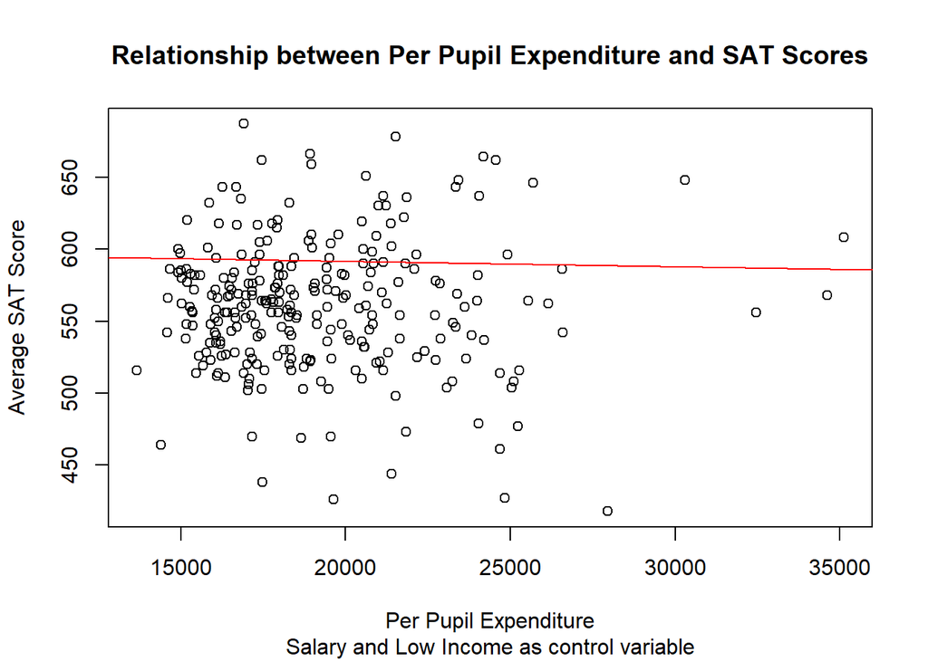

```r
# Scatter plot with regression line

plot(Final_df$`Per Pupil Expenditure`, Final_df$`Avg SAT Score`,
     xlab = "Per Pupil Expenditure", ylab = "Average SAT Score",
     main = "Relationship between Per Pupil Expenditure and SAT Scores",
     sub = "Salary and Low Income as control variable")

# Addiing a regression line

abline(lm(Final_df$`Avg SAT Score` ~ Final_df$`Per Pupil Expenditure` + Final_df$`Avg. Salary` + Final_df$`Low Income`, data = Final_df), col = "red")
```

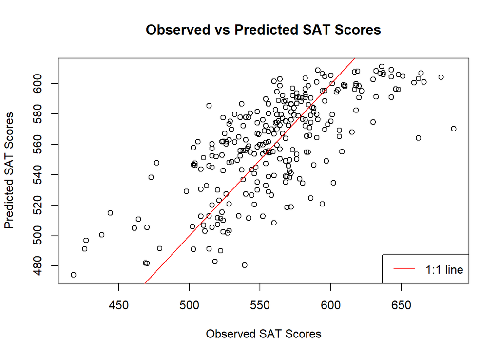

```r
# Extracting predicted values from the model

predicted <- predict(model_2)

# Creating a scatter plot

plot(Final_df$`Avg SAT Score`, predicted,
     xlab = "Observed SAT Scores", ylab = "Predicted SAT Scores",
     main = "Observed vs Predicted SAT Scores")

# Adding a diagonal line for reference

abline(0, 1, col = "red")

# Adding a legend

legend("bottomright", legend = "1:1 line", col = "red", lty = 1)
```

```r
# From the plot comparing predicted and observed SAT scores, it's evident that only a few scores align precisely along the 1:1 line, indicating accurate predictions. However, the majority of scores deviate from this line, suggesting either overestimation or underestimation by the model.
```

This regression analysis aims to explore the relationship between average SAT scores (dependent variable) and three independent variables: per-pupil expenditure, average teacher salary, and the percentage of students from low-income backgrounds (control variable).

- Coefficients: The coefficient estimates represent the relationship between the dependent and independent variables. The intercept coefficient (5.994e+02) indicates the expected average SAT score when all independent variables are zero. The coefficient estimates for per-pupil expenditure, average teacher salary, and the percentage of students from low-income backgrounds (-3.843e-04, 2.750e-04, and -1.497e+00, respectively) represent the change in the average SAT score associated with a one-unit change in each independent variable, holding other variables constant.

- Significance Levels: The significance levels associated with the coefficients are indicated by the p-values. In this analysis, the coefficients for per-pupil expenditure and average teacher salary are not statistically significant (p > 0.05), indicating that they do not have a significant impact on average SAT scores. However, the coefficient for the percentage of students from low-income backgrounds is highly significant (p < 0.001), suggesting that it has a significant effect on average SAT scores.

- Model Fit: The multiple R-squared value (0.5097) indicates that approximately 50.97% of the variance in average SAT scores is explained by the linear relationship with the independent variables included in the model. The adjusted R-squared value (0.5041) adjusts for the number of predictors in the model, providing a more accurate estimate of the proportion of variance explained.

Overall, this regression analysis suggests that the percentage of students from low-income backgrounds has a significant negative impact on average SAT scores, while per-pupil expenditure and average teacher salary do not have a significant effect after controlling for the percentage of low-income students. The model explains a substantial proportion of the variability in average SAT scores, indicating its usefulness in predicting SAT performance based on these variables.

### Model #5

Let’s experiment by swapping the control variable between average salary and graduation rate. This time, we will utilize graduation rate and low income alongside per pupil expenditure to predict the dependent variable of SAT scores.

```r
# Fitting in the model with data.

model_3 <- lm(Final_df$`Avg SAT Score` ~ Final_df$`Per Pupil Expenditure` + Final_df$`% Graduated` + Final_df$`Low Income`, data = Final_df)

# Viewing summary statistics of the regression analysis.

summary(model_3)
```

```
Call:
lm(formula = Final_df$`Avg SAT Score` ~ Final_df$`Per Pupil Expenditure` +
    Final_df$`% Graduated` + Final_df$`Low Income`, data = Final_df)

Residuals:
    Min      1Q  Median      3Q     Max
-88.791 -19.304  -2.485  19.910 104.883

Coefficients:
                                   Estimate Std. Error t value Pr(>|t|)
(Intercept)                       7.605e+02  3.971e+01  19.152  < 2e-16 ***
Final_df$`Per Pupil Expenditure`  4.571e-05  5.627e-04   0.081 0.935312
Final_df$`% Graduated`           -1.457e+00  3.873e-01  -3.763 0.000207 ***
Final_df$`Low Income`            -1.816e+00  1.158e-01 -15.680  < 2e-16 ***
---
Signif. codes:  0 '***' 0.001 '**' 0.01 '*' 0.05 '.' 0.1 ' ' 1

Residual standard error: 30.87 on 265 degrees of freedom
Multiple R-squared:  0.5312,    Adjusted R-squared:  0.5259
F-statistic: 100.1 on 3 and 265 DF,  p-value: < 2.2e-16
```

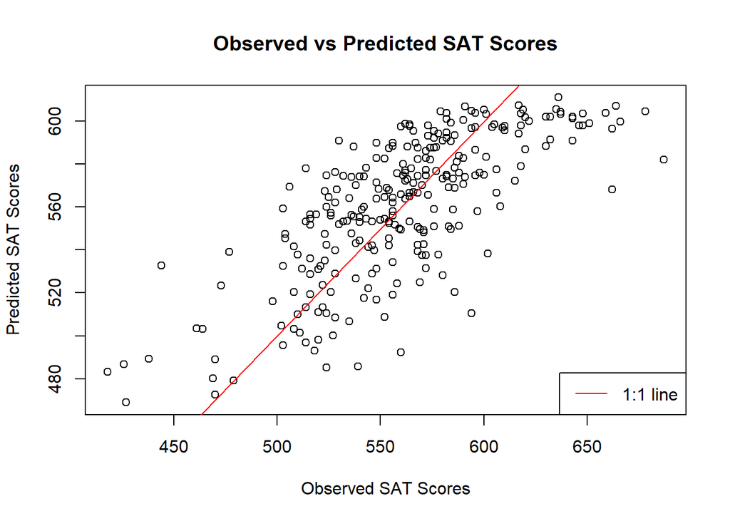

```r
# Extracting predicted values from the model

predicted <- predict(model_3)

# Creating a scatter plot

plot(Final_df$`Avg SAT Score`, predicted,
     xlab = "Observed SAT Scores", ylab = "Predicted SAT Scores",
     main = "Observed vs Predicted SAT Scores")

# Adding a diagonal line for reference

abline(0, 1, col = "red")

# Adding a legend

legend("bottomright", legend = "1:1 line", col = "red", lty = 1)
```

```r
# The model's predictive capabilities remain limited, as evidenced by the prevalence of underfitted or overfitted predictions.
```

This regression analysis explores the relationship between average SAT scores (dependent variable) and three independent variables: per-pupil expenditure, percentage of students graduated, and the percentage of students from low-income backgrounds.

- Coefficients: The coefficient estimates represent the relationship between the dependent and independent variables. The intercept coefficient (7.605e+02) indicates the expected average SAT score when all independent variables are zero. The coefficient estimates for per-pupil expenditure, percentage of students graduated, and the percentage of students from low-income backgrounds (4.571e-05, -1.457e+00, and -1.816e+00, respectively) represent the change in the average SAT score associated with a one-unit change in each independent variable, holding other variables constant.

- Model Fit: The multiple R-squared value (0.5312) indicates that approximately 53.12% of the variance in average SAT scores is explained by the linear relationship with the independent variables included in the model. The adjusted R-squared value (0.5259) adjusts for the number of predictors in the model, providing a more accurate estimate of the proportion of variance explained.

### Model #6

```r
# Fitting in the model with data.

model_4 <- lm(Final_df$`Avg SAT Score` ~ Final_df$`Per Pupil Expenditure` + Final_df$`% Graduated` + Final_df$`Avg. Salary` + Final_df$`Low Income`, data = Final_df)

# Viewing summary statistics of the regression analysis.

summary(model_4)
```

```
Call:
lm(formula = Final_df$`Avg SAT Score` ~ Final_df$`Per Pupil Expenditure` +
    Final_df$`% Graduated` + Final_df$`Avg. Salary` + Final_df$`Low Income`,
    data = Final_df)

Residuals:
    Min      1Q  Median      3Q     Max
-86.613 -19.387  -2.317  19.665 107.022

Coefficients:
                                   Estimate Std. Error t value Pr(>|t|)
(Intercept)                       7.475e+02  4.523e+01  16.524  < 2e-16 ***
Final_df$`Per Pupil Expenditure` -1.147e-04  6.226e-04  -0.184  0.85401
Final_df$`% Graduated`           -1.405e+00  3.973e-01  -3.536  0.00048 ***
Final_df$`Avg. Salary`            1.209e-04  1.998e-04   0.605  0.54570
Final_df$`Low Income`            -1.783e+00  1.279e-01 -13.946  < 2e-16 ***
---
Signif. codes:  0 '***' 0.001 '**' 0.01 '*' 0.05 '.' 0.1 ' ' 1

Residual standard error: 30.9 on 264 degrees of freedom
Multiple R-squared:  0.5319,    Adjusted R-squared:  0.5248
F-statistic: 74.99 on 4 and 264 DF,  p-value: < 2.2e-16
```

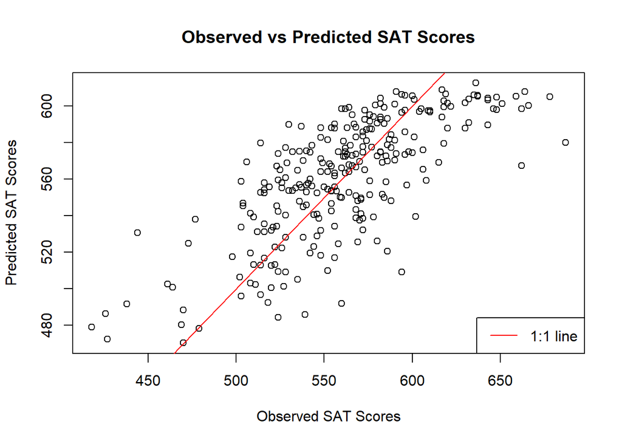

```r
# Extracting predicted values from the model

predicted <- predict(model_4)

# Creating a scatter plot

plot(Final_df$`Avg SAT Score`, predicted,
     xlab = "Observed SAT Scores", ylab = "Predicted SAT Scores",
     main = "Observed vs Predicted SAT Scores")

# Adding a diagonal line for reference

abline(0, 1, col = "red")

# Adding a legend

legend("bottomright", legend = "1:1 line", col = "red", lty = 1)
```

```r
# While this model shows an improvement in predicting SAT scores compared to previous iterations, its success rate remains relatively low.
```

This regression analysis examines the relationship between average SAT scores (dependent variable) and four independent variables: per-pupil expenditure, percentage of students graduated, average teacher salary, and the percentage of students from low-income backgrounds.

- Coefficients: The coefficient estimates represent the relationship between the dependent and independent variables. The intercept coefficient (7.475e+02) indicates the expected average SAT score when all independent variables are zero. The coefficient estimates for per-pupil expenditure, percentage of students graduated, average teacher salary, and the percentage of students from low-income backgrounds (-1.147e-04, -1.405e+00, 1.209e-04, and -1.783e+00, respectively) represent the change in the average SAT score associated with a one-unit change in each independent variable, holding other variables constant.

- Significance Levels: The significance levels associated with the coefficients are indicated by the p-values. In this analysis, the coefficients for per-pupil expenditure and average teacher salary are not statistically significant (p > 0.05), indicating that they do not have a significant impact on average SAT scores. However, the coefficients for the percentage of students graduated and the percentage of students from low-income backgrounds are highly significant (p < 0.001), suggesting that they have a significant effect on average SAT scores.

- Model Fit: The multiple R-squared value (0.5319) indicates that approximately 53.19% of the variance in average SAT scores is explained by the linear relationship with the independent variables included in the model. The adjusted R-squared value (0.5248) adjusts for the number of predictors in the model, providing a more accurate estimate of the proportion of variance explained..

Overall, this regression analysis suggests that the percentage of students graduated and the percentage of students from low-income backgrounds have significant negative impacts on average SAT scores, while per-pupil expenditure and average teacher salary do not have a significant effect after controlling for these variables. The model explains a substantial proportion of the variability in average SAT scores, indicating its usefulness in predicting SAT performance based on these variables.

### Model #7

For this regression model, we will use the average SAT score as our dependent variable, with low income and graduation rates serving as the independent variables.

```r
# Fitting in the model with data.

model_5 <- lm(Final_df$`Avg SAT Score` ~ Final_df$`% Graduated` + Final_df$`Low Income`, data = Final_df)

# Viewing summary statistics of the regression analysis.

summary(model_5)
```

```
Call:
lm(formula = Final_df$`Avg SAT Score` ~ Final_df$`% Graduated` +
    Final_df$`Low Income`, data = Final_df)

Residuals:
    Min      1Q  Median      3Q     Max
-88.677 -19.118  -2.585  20.014 104.788

Coefficients:
                       Estimate Std. Error t value Pr(>|t|)
(Intercept)            761.2850    38.4920  19.778  < 2e-16 ***
Final_df$`% Graduated`  -1.4563     0.3864  -3.769 0.000202 ***
Final_df$`Low Income`   -1.8159     0.1156 -15.711  < 2e-16 ***
---
Signif. codes:  0 '***' 0.001 '**' 0.01 '*' 0.05 '.' 0.1 ' ' 1

Residual standard error: 30.81 on 266 degrees of freedom
Multiple R-squared:  0.5312,    Adjusted R-squared:  0.5277
F-statistic: 150.7 on 2 and 266 DF,  p-value: < 2.2e-16
```

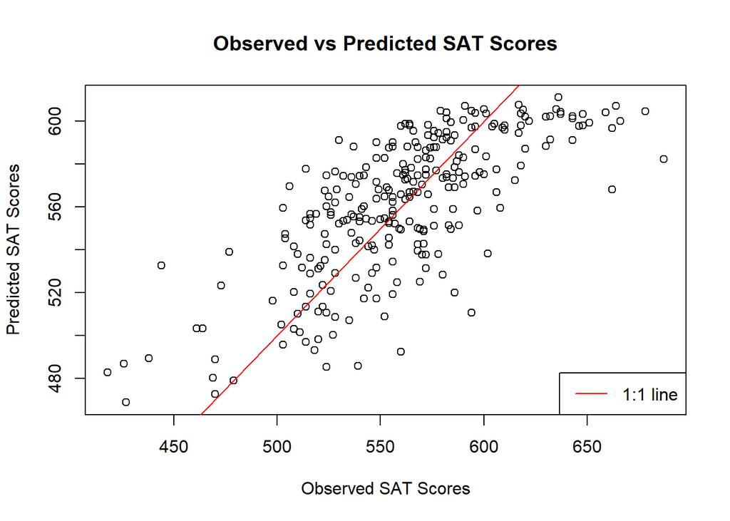

```r
# Extracting predicted values from the model

predicted <- predict(model_5)

# Creating a scatter plot

plot(Final_df$`Avg SAT Score`, predicted,
     xlab = "Observed SAT Scores", ylab = "Predicted SAT Scores",
     main = "Observed vs Predicted SAT Scores")

# Adding a diagonal line for reference

abline(0, 1, col = "red")

# Adding a legend

legend("bottomright", legend = "1:1 line", col = "red", lty = 1)
```

This regression analysis explores the relationship between average SAT scores (dependent variable) and two independent variables: the percentage of students graduated and the percentage of students from low-income backgrounds.

- Coefficients: The coefficient estimates represent the relationship between the dependent and independent variables. The intercept coefficient (761.2850) indicates the expected average SAT score when both independent variables are zero. The coefficient estimates for the percentage of students graduated and the percentage of students from low-income backgrounds (-1.4563 and -1.8159, respectively) represent the change in the average SAT score associated with a one-unit change in each independent variable, holding the other variable constant.

- Significance Levels: The significance levels associated with the coefficients are indicated by the p-values. In this analysis, both the coefficients for the percentage of students graduated and the percentage of students from low-income backgrounds are highly significant (p < 0.001), suggesting that they have a significant impact on average SAT scores.

- Model Fit: The multiple R-squared value (0.5312) indicates that approximately 53.12% of the variance in average SAT scores is explained by the linear relationship with the two independent variables included in the model. The adjusted R-squared value (0.5277) adjusts for the number of predictors in the model, providing a more accurate estimate of the proportion of variance explained.

Overall, this regression analysis suggests that both the percentage of students graduated and the percentage of students from low-income backgrounds have significant negative impacts on average SAT scores. The model explains a substantial proportion of the variability in average SAT scores, indicating its usefulness in predicting SAT performance based on these variables.

## Model Comparison

Throughout our regression analysis, we explored the effects of three main independent variables—per-pupil expenditure, average teacher salary, and graduation rates—on SAT scores. The initial model, which solely considered per-pupil expenditure, lacked statistical significance and exhibited a notably low R-squared value. Subsequent models integrated average teacher salary and graduation rates as independent variables, both of which demonstrated statistical significance. However, their explanatory power remained modest, with R-squared values of approximately 8% and 9%, respectively. The fourth model, incorporating both average teacher salary and per-pupil expenditure along with the control variable of low-income population, produced robust results, exhibiting statistical significance with an R-squared value of around 50%. Nevertheless, only the control variable of low income showed statistical significance. The fifth model, omitting average teacher salary and focusing on per-pupil expenditure, low income as a control variable, and graduation rates, also demonstrated statistical significance with an R-squared value close to 52%. The sixth model included all independent variables along with the control variable of low income, showing statistical significance with a slightly higher R-squared value of 52%. However, in this model, only the low-income variable and graduation rate were significant. The final model comprised only the low-income and graduation rate as independent variables, which exhibited statistical significance with the highest R-squared value of around 53%. Overall, these findings underscore the varying impacts of different independent variables on SAT scores, with the seventh model showcasing the most comprehensive predictive capability.

Throughout our iterative process of developing regression models, we explored various combinations of independent variables. Among these, the seventh model stood out as the most effective in predicting average SAT scores, utilizing graduation rate as the independent variable and low income as the control variable. This model exhibited statistical significance and achieved the highest R-squared value, explaining a substantial portion of the variation. To further evaluate the model’s performance and identify the most suitable option among the alternatives, we will compare the Akaike Information Criterion (AIC), and Bayesian Information Criterion (BIC) values of each model.

```r
# Creating a vector of model names

model_names <- c("Mod_1_h1", "Mod_1_h2", "Mod_1_h3", "Mod_2", "Mod_3", "Mod_4", "Mod_5")

# Creating a vector of AIC scores for each model

aic_scores <- c(AIC(model_1_h1), AIC(model_1_h3), AIC(model_1_h3), AIC(model_2), AIC(model_3), AIC(model_4), AIC(model_5))

# Creating a vector of BIC scores for each model

bic_scores <- c(BIC(model_1_h1), BIC(model_1_h2), BIC(model_1_h3), BIC(model_2), BIC(model_3), BIC(model_4), BIC(model_5))

# Creating a vector of Adjusted R Squared.

adj_r_squared <- c(summary(model_1_h1)$adj.r.squared,
                   summary(model_1_h2)$adj.r.squared,
                   summary(model_1_h3)$adj.r.squared,
                   summary(model_2)$adj.r.squared,
                   summary(model_3)$adj.r.squared,
                   summary(model_4)$adj.r.squared,
                   summary(model_5)$adj.r.squared)

# Creating a vector of number of observations for each model.

n_obs <- c(nobs(model_1_h1),
           nobs(model_1_h2),
           nobs(model_1_h3),
           nobs(model_2),
           nobs(model_3),
           nobs(model_4),
           nobs(model_5))

# Creating the data frame

mod_com <- data.frame(Model = model_names, AIC = aic_scores, BIC = bic_scores,
                      Adj_R_Squared = adj_r_squared, Num_Observations = n_obs)

# Viewing the data frame

print(mod_com)
```

```
     Model      AIC      BIC Adj_R_Squared Num_Observations
1 Mod_1_h1 2814.344 2825.128  -0.003739853              269
2 Mod_1_h2 2787.141 2800.428   0.084321023              269
3 Mod_1_h3 2787.141 2797.925   0.092801582              269
4    Mod_2 2626.619 2644.593   0.504148631              269
5    Mod_3 2614.546 2632.520   0.525911508              269
6    Mod_4 2616.173 2637.742   0.524774583              269
7    Mod_5 2612.553 2626.932   0.527682032              269
```

Based on the comparison of Adjusted R Squared, AIC, and BIC scores, model 5 exhibits competitive value. Therefore, model 5 is selected as the final model due to its lower AIC and BIC values and higher R-squared value of 0.527, indicating that it explains approximately 52.7% of the variation in the dependent variable.

## Conclusion

Based on the analysis conducted, it appears that there is evidence to support my hypotheses. Specifically:

1. *H1-1*: The hypothesis stating that there exists a significant correlation between SAT scores and per-pupil expenditure in Massachusetts district schools is not supported by the regression analysis. While the relationship was found to be statistically insignificant, the direction of the correlation was negative, indicating that as per-pupil expenditure increases, SAT scores tend to decrease.

2. *H1-2*: Similarly, the hypothesis suggesting a significant correlation between SAT scores and average teacher salaries in Massachusetts district schools is supported. The regression analysis revealed a positive relationship between average teacher salaries and SAT scores, indicating that higher teacher salaries are associated with higher SAT scores.

3. *H1-3*: Finally, the hypothesis proposing a significant correlation between SAT scores and student graduation rates in Massachusetts district schools is also supported. The regression analysis demonstrated a positive relationship between graduation rates and SAT scores, suggesting that schools with higher graduation rates tend to have higher SAT scores.

Overall, the outcomes of the regression analysis corroborate the second and third hypotheses, uncovering significant correlations between SAT scores and average teacher salaries, along with student graduation rates in Massachusetts district schools. Moreover, our control variable of Low Income emerges as highly significant when assessing our specified dependent variable. Notably, when all independent variables are included in the model, per pupil expenditure and average teacher salary lose their significance, underscoring that graduation rate and low income population serve as superior predictors as independent variables, encapsulating the explanatory power provided by per pupil expenditure and teacher salaries.

## Regression Diagnostics

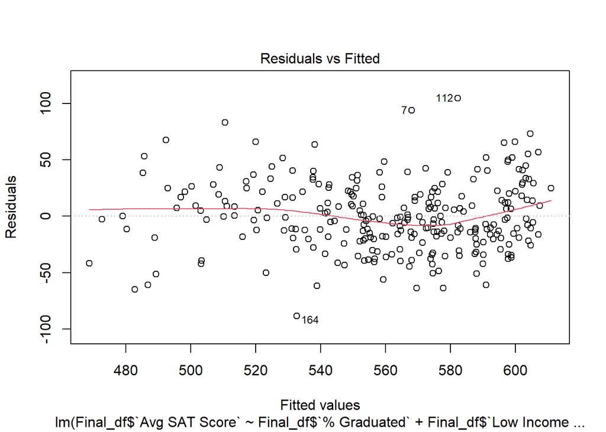

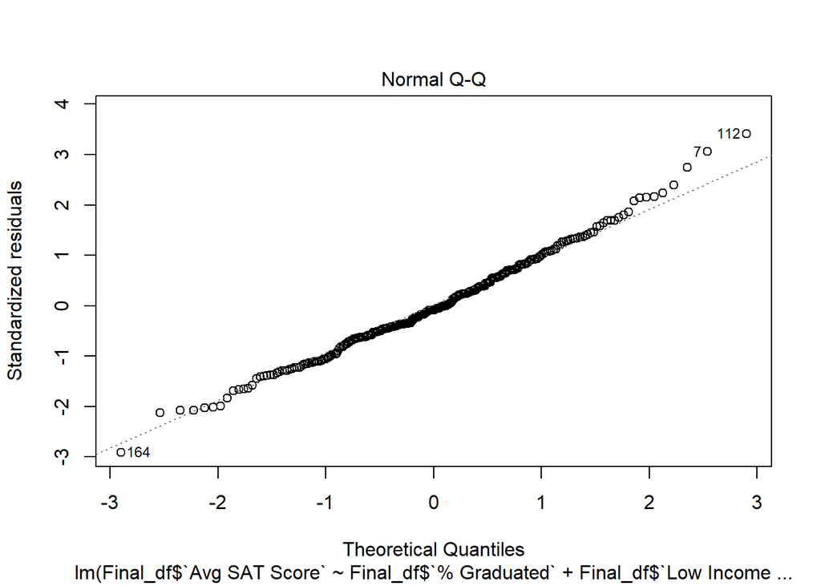

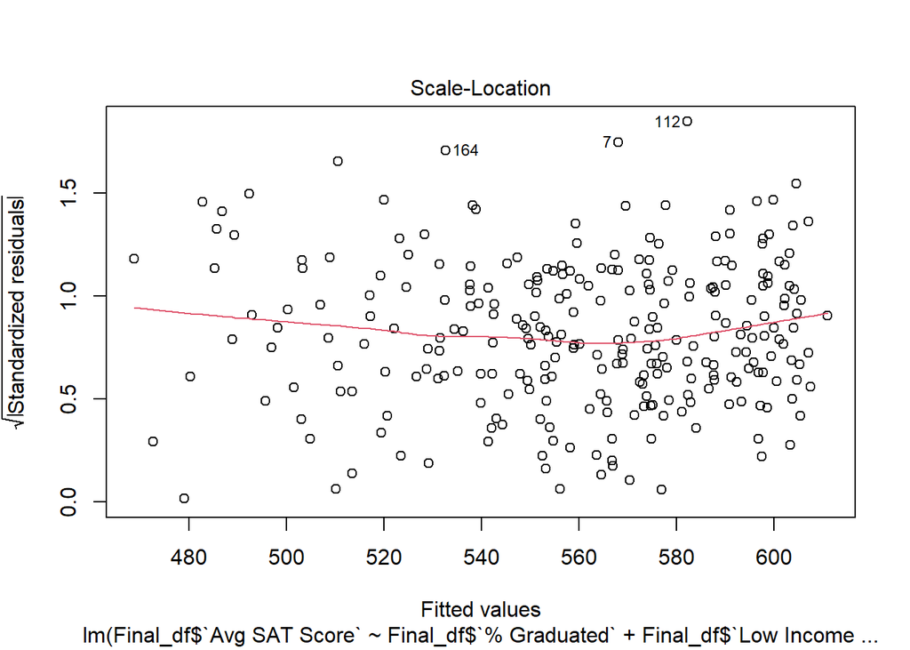

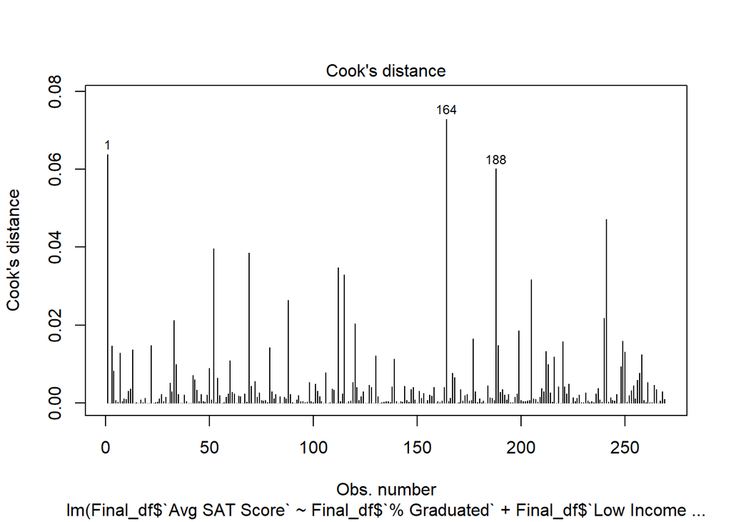

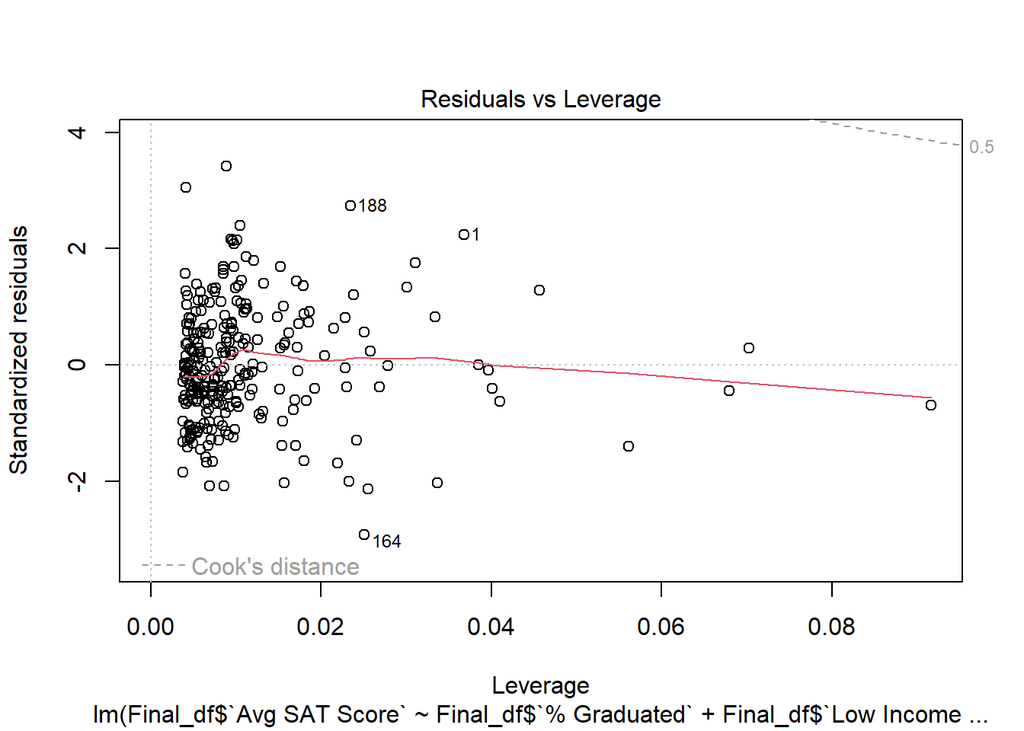

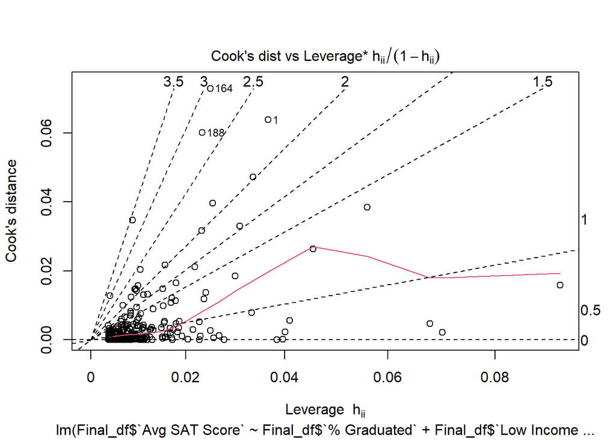

```r
# Running regression diagnostics plots

plot(model_5, which = 1:6)
```

Diagnostic plots are essential tools for assessing the assumptions and performance of a regression model. Here’s the interpretetion of the diagnostic plots for the final model:

1. Residuals vs Fitted Plot: This plot examines the relationship between the residuals (the differences between observed and predicted values) and the fitted values (the predicted values from the model). Ideally, the points should be randomly scattered around the horizontal line at zero, indicating that the residuals have constant variance across all levels of the fitted values. Patterns such as curvature or funnel shape may suggest heteroscedasticity or nonlinearity in the model. The points for our model are randomly scattered around the horizontal line at zero indication constant variance almost uptill the end where we can see a certain pattern.

3. Scale-Location Plot: Also known as the “Spread-Location” plot, this graph assesses the homogeneity of variance (homoscedasticity) across the range of fitted values. The plot shows the square root of the standardized residuals against the fitted values. Ideally, the points should form a horizontal band with constant width, indicating homoscedasticity. A trend in the points suggests heteroscedasticity. Our model has some trend going on with the line showing a bit of heteroscedasticity.

6. Cook’s distance vs leverage: The Cook’s distance vs leverage plot is a graphical representation of Cook’s distance against leverage, which is a measure of how much an observation differs from the mean of the independent variables. This plot helps visualize influential data points that have both high leverage and high influence on the regression model. In this plot, influential data points are typically those located in the upper-right quadrant, indicating both high leverage and high influence. For our model there are no such data points which influence the model too much.

By examining these diagnostic plots, we can assess the assumptions of the regression model, identify potential issues such as nonlinearity, heteroscedasticity, or influential outliers, and make informed decisions about model refinement or further analysis.

To beautifully present the results of our regression analysis models, we will utilize the stargazer package. This package allows us to generate nicely formatted tables summarizing the key statistics and coefficients from our regression models. By using stargazer, we can create elegant tables that are easy to interpret and visually appealing. Let’s employ the stargazer package to tabulate and present the results of our regression analysis models in a visually appealing format.

```r
# Loading the required library

library(stargazer)
# Creating a list for all of the models

models_list <- list(model_1_h1, model_1_h2, model_1_h3, model_2, model_3, model_4, model_5)

# Using the stargazer to generate a summarising table for the models

stargazer(models_list, type = "text")
```

```
=============================================================================================================================================================================================
                                                                                                 Dependent variable:
                        ---------------------------------------------------------------------------------------------------------------------------------------------------------------------
                                                                                                   `Avg SAT Score`
                                (1)                   (2)                     (3)                     (4)                     (5)                      (6)                     (7)
---------------------------------------------------------------------------------------------------------------------------------------------------------------------------------------------
`Per Pupil Expenditure`      -0.00003                                                               -0.0004                 0.00005                  -0.0001
                              (0.001)                                                               (0.001)                 (0.001)                  (0.001)

`Avg. Salary`                                      0.001***                                         0.0003                                           0.0001
                                                   (0.0002)                                        (0.0002)                                         (0.0002)

`% Graduated`                                                              2.258***                                        -1.457***                -1.405***               -1.456***
                                                                            (0.424)                                         (0.387)                  (0.397)                 (0.386)

`Low Income`                                                                                       -1.497***               -1.816***                -1.783***               -1.816***
                                                                                                    (0.101)                 (0.116)                  (0.128)                 (0.116)

Constant                    561.321***            462.904***              351.889***              599.417***               760.516***              747.463***               761.285***
                             (15.883)              (19.480)                (39.264)                (17.482)                 (39.710)                (45.234)                 (38.492)

---------------------------------------------------------------------------------------------------------------------------------------------------------------------------------------------
Observations                    269                   269                     269                     269                     269                      269                     269
R2                            0.00001                0.088                   0.096                   0.510                   0.531                    0.532                   0.531
Adjusted R2                   -0.004                 0.084                   0.093                   0.504                   0.526                    0.525                   0.528
Residual Std. Error      44.915 (df = 267)     42.899 (df = 267)       42.700 (df = 267)       31.568 (df = 265)       30.868 (df = 265)        30.905 (df = 264)       30.810 (df = 266)
F Statistic             0.001 (df = 1; 267) 25.679*** (df = 1; 267) 28.415*** (df = 1; 267) 91.828*** (df = 3; 265) 100.098*** (df = 3; 265) 74.986*** (df = 4; 264) 150.707*** (df = 2; 266)
=============================================================================================================================================================================================
Note:                                                                                                                                                             *p<0.1; **p<0.05; ***p<0.01
```